# About

Marina Bluma

2021-04-03

# Hello, I am Marina!

By occupation, I am a Marie Curie PhD researcher in neuroimaging and neurodegeneration. During my PhD, I worked at the lab of high-resolution EEG in Rome, where my studies were focused on resting-state EEG biomarkers of Alzheimer’s disease. As a Marie Curie fellow, I was very lucky to be able to visit other labs and research centers. Specifically, I got to spend some time at the MarioNegri Institute in Milan, where I learned from Dr. Daniele Tolomeo about neuroimaging in small rodents. After that, I sneaked into the Computational Neuroimaging laboratory led by Prof. Mallar Chakravarty, where I spent the most invaluable time investigating the effects of deep brain stimulation on functional brain networks in Alzheimer’s disease mouse models (project interrupted by the COVID), and absorbing in fresh ideas. Through this experience, I learned a lot about methods for multimodal data fusion in neuroimaging, statistical modeling, and high-performance computing. Prior to that, I obtained my Master’s degree in interdisciplinary Neuroscience in Frankfurt am Main, where for my research project I focused on aberrant reward processing in neurodevelopmental conditions with fMRI, and later on got my first teaching experience at the University of Giessen. And further back, I was born and raised in St. Petersburg, Russia, where I also earned my diploma in Clinical Psychology and got interested in scientific work, while recording eye movements in patients diagnosed on the schizophrenia spectrum.

I like R, FSL, ANTs, shell, computing on a cluster, and reproducible open science tools. I love hierarchical random-effects models, effect sizes over p-values, sci-hub, and data-driven approaches. I am also greatly into learning new things and currently breaking my head over python and scikit-learn tools (or algorithms that are often grouped under “machine learning” term). In my future work, I want to investigate factors contributing to the heterogeneity of Alzheimer’s disease or other conditions related to pathological aging with data-driven approaches. I’m specifically interested in sex-differences in AD.

# Photo

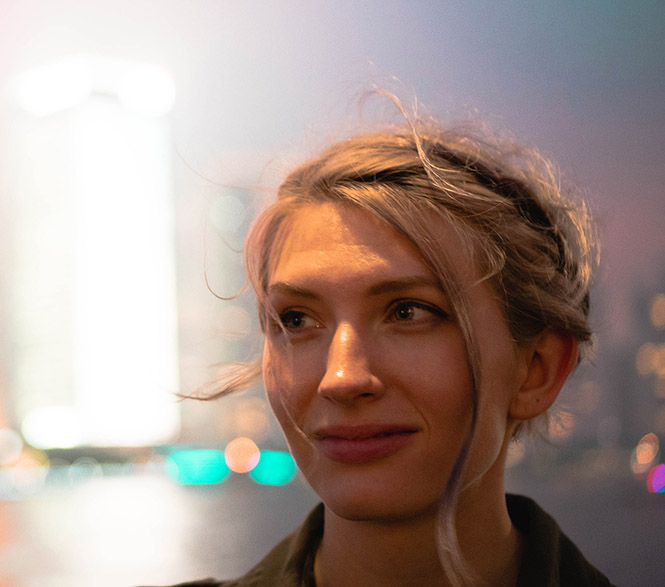